# Assignment_week_12

Kristoffer Segerstroem 2025-03-21

```r
knitr::opts_chunk$set(echo = TRUE,
                      warning = TRUE,
                      message = TRUE)

library(tidyverse)
# For text mining:
library(pdftools)  # Used to extract text from PDF files
```

```r
library(tidytext)  # Facilitates text analysis by working with words in a 'tidy' format
library(textdata)  # Contains various sentiment dictionaries
library(ggwordcloud)  # Used to create word clouds
```

# Get the Game of Thrones text:

```r
got_path <- "data/got.pdf"
got_text <- pdf_text(got_path)  # Extracts text from the PDF file as a vector of strings (one per page)
```

# Some wrangling:

```r
got_df <- data.frame(got_text) %>%
  mutate(text_full = str_split(got_text, pattern = '\\n')) %>%  # Splits the text by line breaks
  unnest(text_full) %>%  # 'Unnests' the listed text so each line becomes a row in the dataframe
  mutate(text_full = str_trim(text_full))  # Removes leading and trailing spaces from each line
```

# Get the tokens (individual words) in tidy format

```r
got_tokens <- got_df %>%
  unnest_tokens(word, text_full)  # Splits the text into individual words (tokens), so each row contains a single word

got_tokens
```

```
## # A tibble: 297,815 × 2
##    got_text                                                                word
##    <chr>                                                                   <chr>
##  1 "                 A GAME OF THRONES\n             Book One of A Song o… a
##  2 "                 A GAME OF THRONES\n             Book One of A Song o… game
##  3 "                 A GAME OF THRONES\n             Book One of A Song o… of
##  4 "                 A GAME OF THRONES\n             Book One of A Song o… thro…
##  5 "                 A GAME OF THRONES\n             Book One of A Song o… book
##  6 "                 A GAME OF THRONES\n             Book One of A Song o… one
##  7 "                 A GAME OF THRONES\n             Book One of A Song o… of
##  8 "                 A GAME OF THRONES\n             Book One of A Song o… a
##  9 "                 A GAME OF THRONES\n             Book One of A Song o… song
## 10 "                 A GAME OF THRONES\n             Book One of A Song o… of
## # ℹ 297,805 more rows
```

# Remove stop words:

```r
got_stop <- got_tokens %>%
  anti_join(stop_words) %>%  # Removes stop words (commonly used words like 'the', 'and', 'of') that do not carry analytical value
  select(-got_text)  # Removes the original text column as it is no longer needed
```

# Count the words

```r
got_stop %>%
  count(word) %>%
  arrange(-n)
```

```
## # A tibble: 11,294 × 2
##    word       n
##    <chr>  <int>
##  1 lord    1341
##  2 ser     1023
##  3 jon      787
##  4 ned      743
##  5 tyrion   591
##  6 eyes     567
##  7 hand     567
##  8 king     542
##  9 father   512
## 10 told     504
## # ℹ 11,284 more rows
```

# Word cloud of GoT words

```r
got_top100 <- got_stop %>%
  count(word) %>%  # Counts the occurrences of each word
  arrange(-n) %>%  # Sorts words by frequency
  head(100)  # Keeps only the 100 most frequent words
```

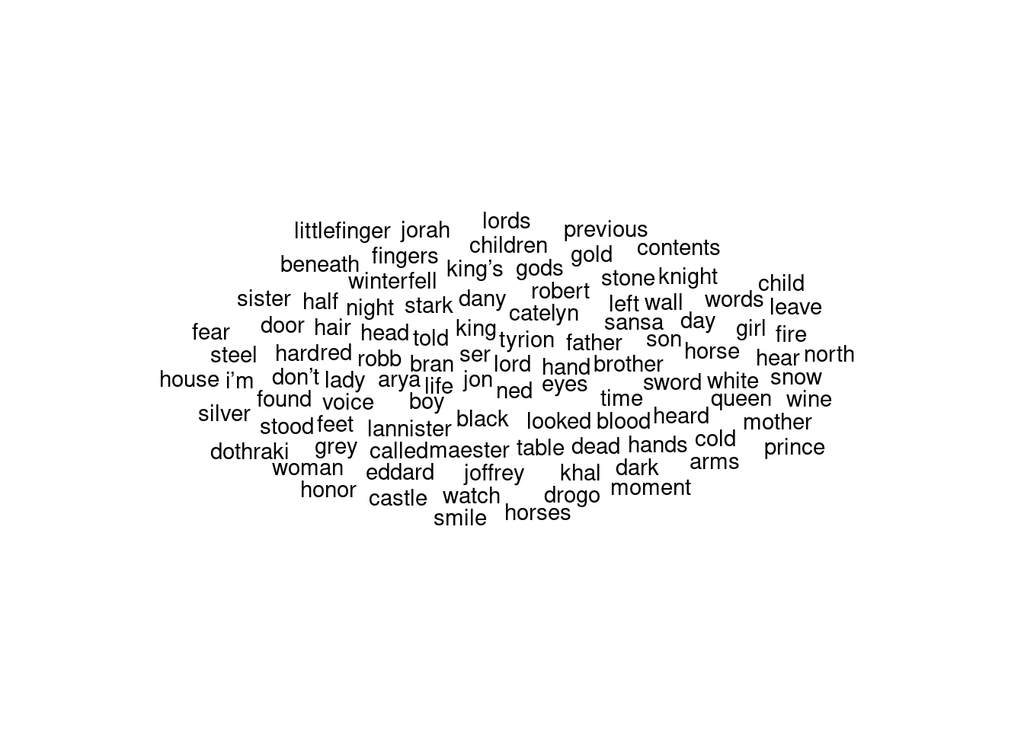

```r
got_cloud <- ggplot(data = got_top100, aes(label = word)) +
  geom_text_wordcloud() +  # Visualizes the words in a word cloud
  theme_minimal()

got_cloud
```

# Let’s make the word cloud af star

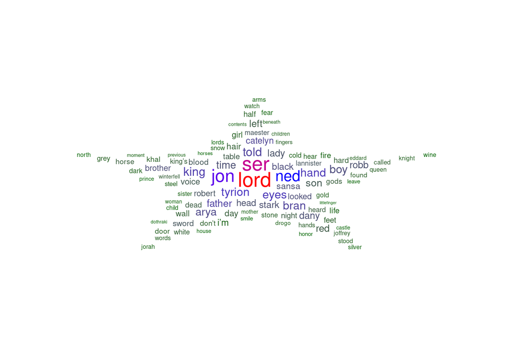

```r
ggplot(data = got_top100, aes(label = word, size = n)) +
  geom_text_wordcloud_area(aes(color = n), shape = "star") +
  scale_size_area(max_size = 12) +
  scale_color_gradientn(colors = c("darkgreen","blue","red")) +
  theme_minimal()
```

# Sentiment analysis with afinn:

### “afinn”: Words ranked from -5 (very negative) to +5 (very positive)

```r
got_afinn <- got_stop %>%
  inner_join(get_sentiments("afinn"))  # Matches words with sentiment scores from the AFINN lexicon (-5 to +5)
```

## The negative words

```r
get_sentiments(lexicon = "afinn")
```

```
## # A tibble: 2,477 × 2
##    word       value
##    <chr>      <dbl>
##  1 abandon       -2
##  2 abandoned     -2
##  3 abandons      -2
##  4 abducted      -2
##  5 abduction     -2
##  6 abductions    -2
##  7 abhor         -3
##  8 abhorred      -3
##  9 abhorrent     -3
## 10 abhors        -3
## # ℹ 2,467 more rows
```

```r
# Note: may be prompted to download (yes)
```

## The positive words

```r
library(tidytext)
afinn <- get_sentiments("afinn")
afinn_pos <- afinn %>% filter(value > 0) #finds the sentiments with a greater value than 0
head(afinn_pos)
```

```
## # A tibble: 6 × 2
##   word      value
##   <chr>     <dbl>
## 1 abilities     2
## 2 ability       2
## 3 aboard        1
## 4 absolve       2
## 5 absolved      2
## 6 absolves      2
```

# Word association with NRC

```r
get_sentiments(lexicon = "nrc")
```

```
## # A tibble: 13,872 × 2
##    word        sentiment
##    <chr>       <chr>
##  1 abacus      trust
##  2 abandon     fear
##  3 abandon     negative
##  4 abandon     sadness
##  5 abandoned   anger
##  6 abandoned   fear
##  7 abandoned   negative
##  8 abandoned   sadness
##  9 abandonment anger
## 10 abandonment fear
## # ℹ 13,862 more rows
```

# Plot sentiment scores:

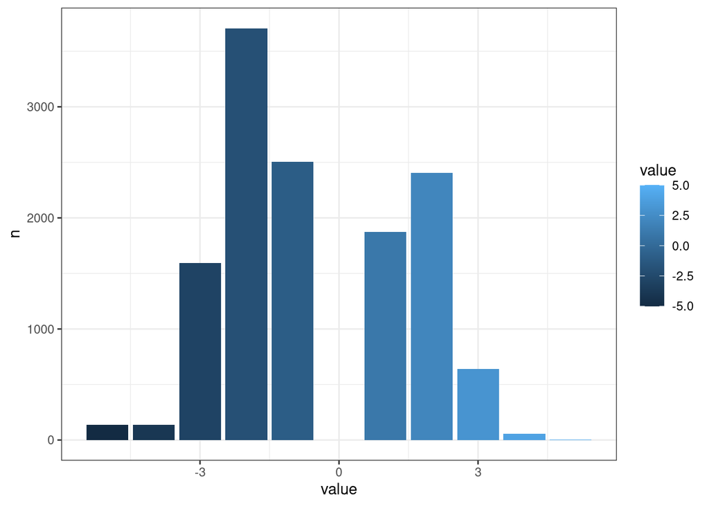

```r
got_afinn_hist <- got_afinn %>%
  count(value)  # Counts the number of words for each sentiment score

ggplot(data = got_afinn_hist, aes(x = value, y = n)) +
  geom_col(aes(fill = value)) +  # Visualizes sentiment scores with a bar chart
  theme_bw()
```

# Investegate which words have a sentiment score of 2 (quite positive)

```r
got_afinn2 <- got_afinn%>%
  filter(value == 2)
got_afinn2%>%
  distinct(word)
```

```
## # A tibble: 201 × 1
##    word
##    <chr>
##  1 smile
##  2 fine
##  3 glory
##  4 hope
##  5 smiled
##  6 care
##  7 strength
##  8 peaceful
##  9 honor
## 10 carefully
## # ℹ 191 more rows
```

```r
#These commandoes isolates the 2-score words
```

# Finding the unique 2-score words

```r
unique(got_afinn2$word) #finds the unique words
```

```
##   [1] "smile"           "fine"            "glory"           "hope"
##   [5] "smiled"          "care"            "strength"        "peaceful"
##   [9] "honor"           "carefully"       "slick"           "top"
##  [13] "gained"          "comfort"         "sweet"           "courage"
##  [17] "daring"          "elegant"         "justice"         "heroes"
##  [21] "fair"            "strong"          "brave"           "solid"
##  [25] "proud"           "mercy"           "rescue"          "swift"
##  [29] "smiling"         "true"            "noble"           "saved"
##  [33] "gift"            "treasures"       "favorite"        "clean"
##  [37] "rich"            "fearless"        "fortunate"       "likes"
##  [41] "earnest"         "generous"        "chances"         "smiles"
##  [45] "hug"             "kiss"            "approved"        "fond"
##  [49] "honored"         "consent"         "peace"           "powerful"
##  [53] "worthy"          "humor"           "entertaining"    "save"
##  [57] "sincerely"       "festive"         "careful"         "stronger"
```

[output cut: 36 more lines]

[figure not shown]

```r
got_afinn2_n <- got_afinn2 %>%
  count(word, sort = TRUE) %>%
  mutate(word = fct_reorder(factor(word), n)) #set up for the ggplot


ggplot(data = got_afinn2_n, aes(x = word, y = n)) +
  geom_col() +
  coord_flip() +
  theme_bw()
```

### This was too big - I dont quite know how to cut down the amount of words

# Let’s find the median and mean of the sentiment of the words

```r
got_summary <- got_afinn %>%
  summarize(
    mean_score = mean(value),
    median_score = median(value)
  )

print(got_summary)
```

```
## # A tibble: 1 × 2
##   mean_score median_score
##        <dbl>        <dbl>
## 1     -0.542           -1
```

### The words in the GoT.pdf are not quite as positive, as they have a median score of -1

# NRC lexicon for sentiment analysis

```r
got_nrc <- got_stop %>%
  inner_join(get_sentiments("nrc"))  # Matches words with the NRC lexicon, which categorizes words into different emotions
```

## Before we do the sentiment analysis, I will find out, which words are excluded

```r
got_exclude <- got_stop %>%
  anti_join(get_sentiments("nrc")) #finds the excluded wrods
got_exclude_n <- got_exclude %>%
  count(word, sort = TRUE) #counts the excluded words

head(got_exclude_n) #shows the result
```

```
## # A tibble: 6 × 2
##   word       n
##   <chr>  <int>
## 1 ser     1023
## 2 jon      787
## 3 ned      743
## 4 tyrion   591
## 5 eyes     567
## 6 hand     567
```

### Above are the excluded words

# Now we can continue analysing the sentiment

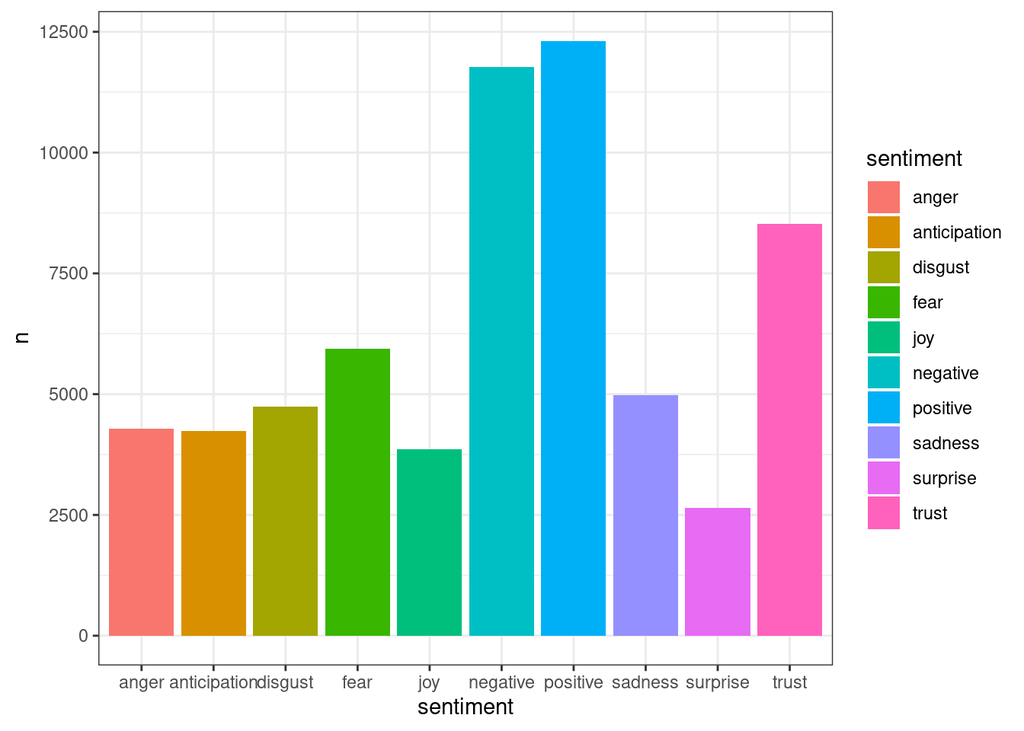

```r
got_nrc_n <- got_nrc %>%
  count(sentiment, sort = TRUE)  # Counts how many words belong to each sentiment category

ggplot(data = got_nrc_n, aes(x = sentiment, y = n, fill = sentiment)) +
  geom_col() +  # Visualizes the results in a bar chart
  theme_bw()
```